# Practive Activity 9: Regression

Author

Jamie Thompson

```r
library(tidyverse)
```

# **1 Data**

The dataset “mystery_animal.csv” contains the weights of a particular animal before and after a year of eating only roasted duck.

```r
animals <- read.csv(here::here("supporting_artifacts",
                               "learning_targets",
                               "Data",
                               "mystery_animal.csv")
                    )
```

# **2 Linear Regression**

Fit a linear regression to determine if the Duck Diet is associated with the animal gaining weight, losing weight, or neither.

```r
animals_lm <- lm(weight_after ~ weight_before, data = animals)
broom::augment(animals_lm)
```

```
# A tibble: 569 × 8
   weight_after weight_before .fitted .resid    .hat .sigma .cooksd .std.resid
          <dbl>         <int>   <dbl>  <dbl>   <dbl>  <dbl>   <dbl>      <dbl>
 1         286.           215    259.   26.7 0.00355   10.9 0.0106        2.44
 2         289.           218    263.   26.2 0.00348   10.9 0.00991       2.38
 3         291.           220    265.   25.8 0.00343   10.9 0.00949       2.35
 4         293.           222    267.   25.6 0.00338   10.9 0.00922       2.33
 5         293.           222    267.   25.4 0.00338   11.0 0.00908       2.31
 6         294.           223    269.   25.2 0.00336   11.0 0.00888       2.30
 7         296.           225    271.   24.8 0.00331   11.0 0.00849       2.26
 8         298.           227    273.   24.2 0.00326   11.0 0.00798       2.21
 9         299.           229    276.   23.4 0.00322   11.0 0.00737       2.14
10         299.           230    277.   22.1 0.00320   11.0 0.00647       2.01
# … with 559 more rows
```

# **3 Residuals**

Plot the residuals (observed value minus predicted value) of your linear model versus `weight_before`.

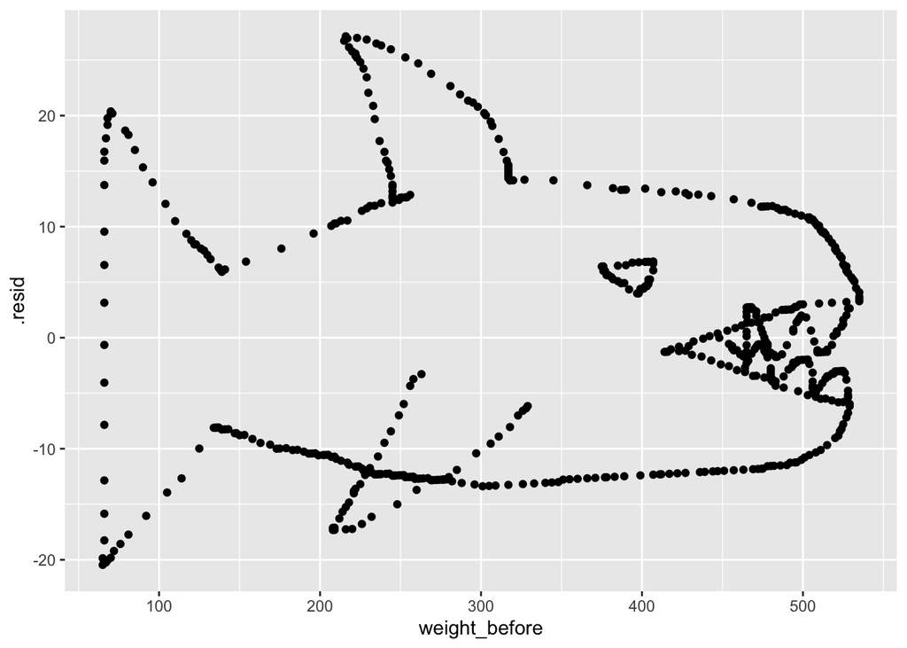

```r
animals_lm |>
  broom::augment() |>
  ggplot(mapping = aes(y = .resid, x = weight_before)) +
  geom_point()
```

# **4 Mystery Animal**

What animal do you see?

# **Practice Activity 9.2: Simulation**

A man named Professor Harold Hill wanders into your small town. He claims to be selling top-quality instruments for a marching band. He begins selling his instruments to all the children in town.

You are suspicious of Professor Hill, and think that perhaps he is selling instruments made of sub par materials, to scam the townsfolk.

You do some research on the weights of properly crafted brass instruments, and you learn the following facts:

- Trombones weights are Normally distributed, with a mean weight of 4.6 pounds and a standard deviation of 0.8 pounds.
- Trumpet weights are Uniformly distributed between 1.5 and 3.5 pounds.
- Reed instruments (like clarinets, bassoons, and saxophones) have weights that are Chi-Square distributed with 4 degrees of freedom.

# **1 Remember**

**Four Types of Calculations**

- `p` – stands for probability (left tail area for a given value of x)
- `r` – stands for random (for generating data)
- `q` – stands for quantile (for a given probability)
- `d` – stands for density (of the distribution at a given value of x)

**Distributions**

- The Normal distribution functions end with `norm`
- The Uniform distribution functions end with `unif`
- The Chi-Square distribution functions end with `chisq`

# **2 Warm-up**

- What is the 95th percentile for trumpet weight?

```r
qunif(0.95, min = 1.5, max = 3.5)
```

```
[1] 3.4
```

- What is the 10th percentile for trombone weight?

```r
qnorm(.1, mean = 4.6, sd = 0.8)
```

```
[1] 3.574759
```

- About what percent of trombones do you expect to be more than 5 pounds?

```r
pnorm(5, mean = 4.6, sd = 0.8, lower.tail = FALSE)
```

```
[1] 0.3085375
```

- About what percent of reed instruments do you expect to be more than 5 pounds?

```r
pchisq(5, df = 4, lower.tail = FALSE)
```

```
[1] 0.2872975
```

- Simulate 100 random trombone weights. How many of them were below 4 pounds?

```r
fake_data_trombone <- (weight = rnorm(n = 100,
                                            mean = 4.6,
                                            sd = 0.8)
                             )
sum(fake_data_trombone < 4)
```

```
[1] 24
```

# **3 Catching a Con**

You manage to intercept a shipping notice for delivery to Professor Hill. It says the following:

“”

`Wells Fargo Shipment 1957`

`To: Harold Hill, Mason City, Iowa From: Music Factory, Gary, Indiana`

`Total Shipped Weight: 4532 lbs.`

“”

This is your chance to catch Professor Hill in his lie!

- First, write a function that samples the correct number of weights of trombones, cornets (trumpets), and reed instruments (saxophones, clarinets, bassoons), and then returns the total weight of the shipment.
- Then, use that function to create random samples of the total weight of 1000 possible shipments.

## Evidence 1

```r
music_man <- function(n_tromb, n_cor, n_reed){

  trombones <- rnorm(n_tromb, mean = 4.6, sd = 0.8)
  cornets <- runif(n_cor, min = 1.5, max = 3.5)
  reeds <- rchisq(n_reed, df = 4)

  return(sum(trombones, cornets, reeds))

}

set.seed(1957)

my_weights <- rerun(.n = 1000,
                    music_man(n_tromb = 76,
                              n_cor = 110,
                              n_reed = (1035)
                              )
                    ) |>
  flatten_dbl()

sum(my_weights < 4532)
```

```
[1] 7
```

How many of these samples had a weight less than Prof. Hill’s shipment? Do you believe Professor Hill is lying, or not?